# Counts And Ordering

# Goal

This notebook shows how to visualize categorical counts and order categories so the plot answers a clearer question.

# Analytic Questions

We will use a cleaned Census race/ethnicity dataset to ask:

- How many state rows appear for each race/ethnicity category?
- Which race/ethnicity categories account for the largest total population in this file?
- How does ordering change what the reader can see?

# Load Data

```r
census_path <- "data/real/census_state_race_ethnicity_long.csv"

census <- read_csv(census_path, show_col_types = FALSE)

census |>
  glimpse()
```

```
Rows: 357
Columns: 8
$ state                           <chr> "MA", "MA", "MA", "MA", "MA", "MA", "M…
$ state_name                      <chr> "Massachusetts", "Massachusetts", "Mas…
$ rank                            <dbl> 1, 1, 1, 1, 1, 1, 1, 2, 2, 2, 2, 2, 2,…
$ total_population                <dbl> 6892503, 6892503, 6892503, 6892503, 68…
$ race_ethnicity                  <chr> "American Indian and Alaska Native", "…
$ race_ethnicity_population       <dbl> 9387, 504900, 457055, 887685, 1607, 92…
$ total_race_ethnicity_population <dbl> 6701639, 6701639, 6701639, 6701639, 67…
$ share                           <dbl> 0.0014007021, 0.0753397788, 0.06820048…
```

Each row is one race/ethnicity category within one state.

# Count Rows

First, count how many rows appear for each race/ethnicity category.

```r
category_counts <- census |>
  count(race_ethnicity, sort = TRUE)

category_counts
```

```
# A tibble: 7 × 2
  race_ethnicity                                 n
  <chr>                                      <int>
1 American Indian and Alaska Native             51
2 Asian                                         51
3 Black                                         51
4 Hispanic or Latino                            51
5 Native Hawaiian and Other Pacific Islander    51
6 Other                                         51
7 White                                         51
```

Start with data and mappings.

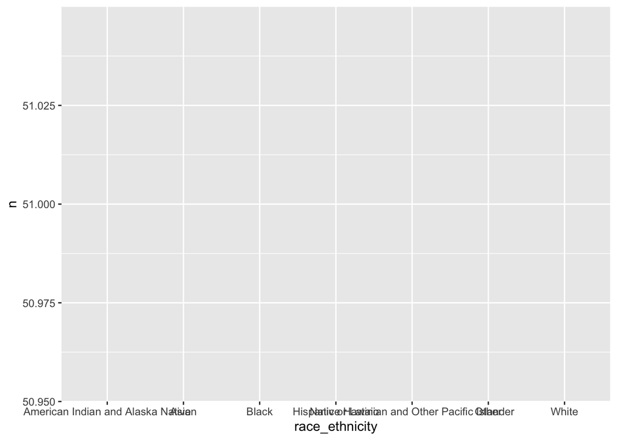

```r
p1 <- ggplot(
  category_counts,
  aes(x = race_ethnicity, y = n)
)

p1
```

Add columns.

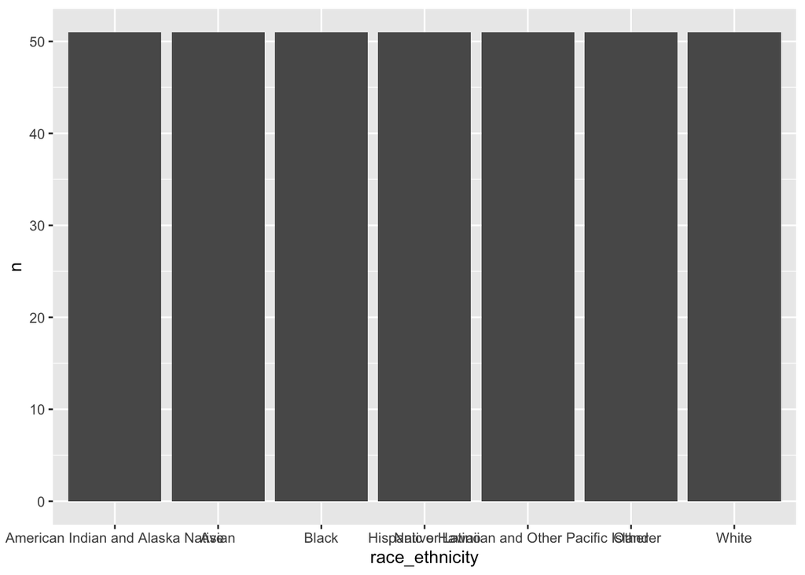

```r
p2 <- p1 +
  geom_col()

p2
```

This plot is not very informative because every category appears once per state.

It is still useful as a reminder: before plotting counts, ask what the rows mean.

# Summarize Population By Category

A more meaningful categorical summary is total included population by race/ethnicity category.

```r
category_population <- census |>
  group_by(race_ethnicity) |>
  summarise(
    total_population = sum(race_ethnicity_population),
    .groups = "drop"
  ) |>
  arrange(desc(total_population))

category_population
```

```
# A tibble: 7 × 2
  race_ethnicity                             total_population
  <chr>                                                 <dbl>
1 White                                             191697647
2 Hispanic or Latino                                 62080044
3 Black                                              39940338
4 Asian                                              19618719
5 American Indian and Alaska Native                   2251699
6 Other                                               1689833
7 Native Hawaiian and Other Pacific Islander           622018
```

Now each row is one race/ethnicity category.

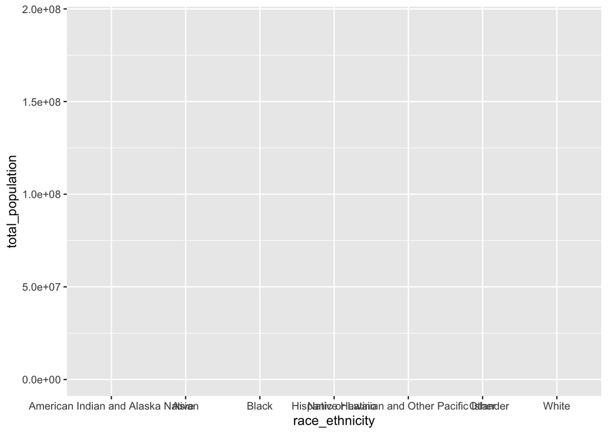

```r
p1 <- ggplot(
  category_population,
  aes(x = race_ethnicity, y = total_population)
)

p1
```

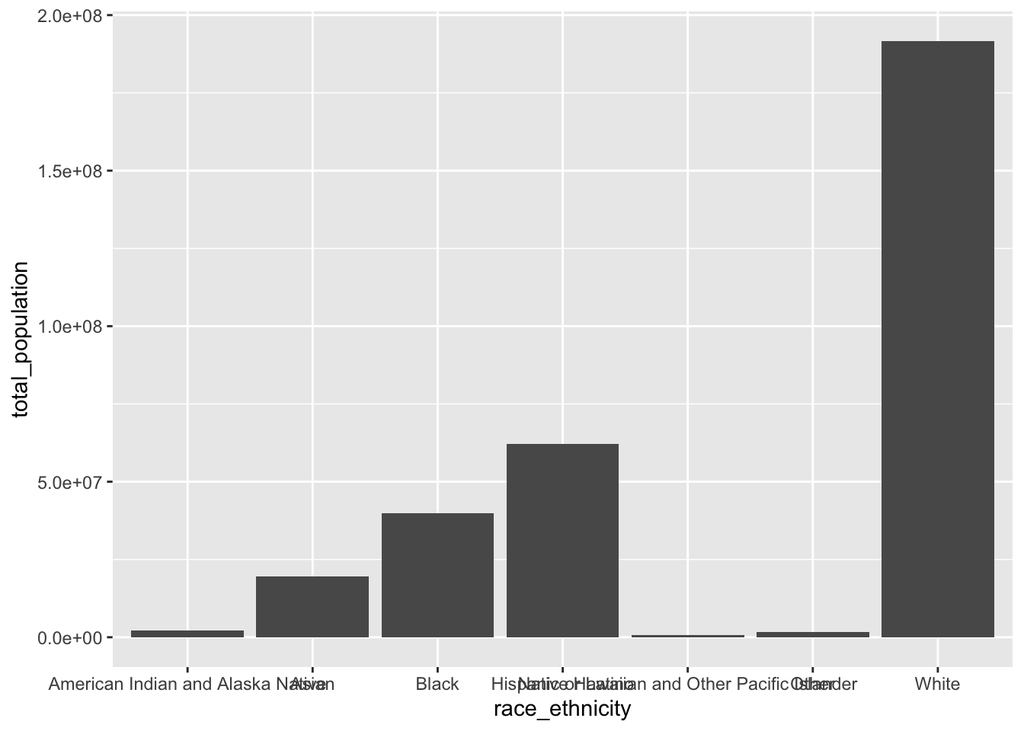

```r
p2 <- p1 +
  geom_col()

p2
```

# Order The Categories

The labels are hard to read, and alphabetical order does not help answer the ranking question.

Reorder by total population.

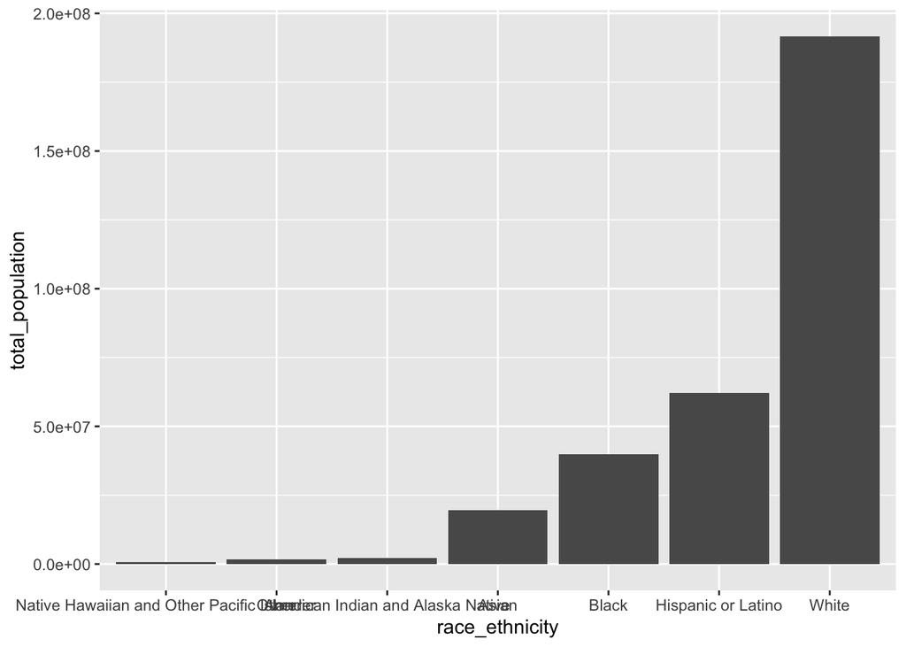

```r
category_population_ordered <- category_population |>
  mutate(race_ethnicity = reorder(race_ethnicity, total_population))

p3 <- ggplot(
  category_population_ordered,
  aes(x = race_ethnicity, y = total_population)
) +
  geom_col()

p3
```

Flip the coordinates so the category labels are readable.

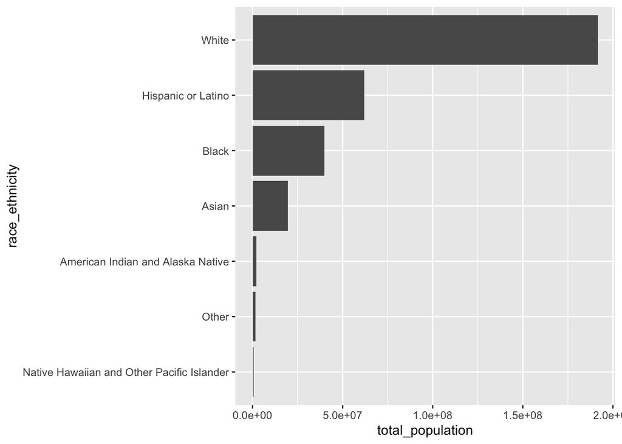

```r
p4 <- p3 +
  coord_flip()

p4
```

Add labels and a theme.

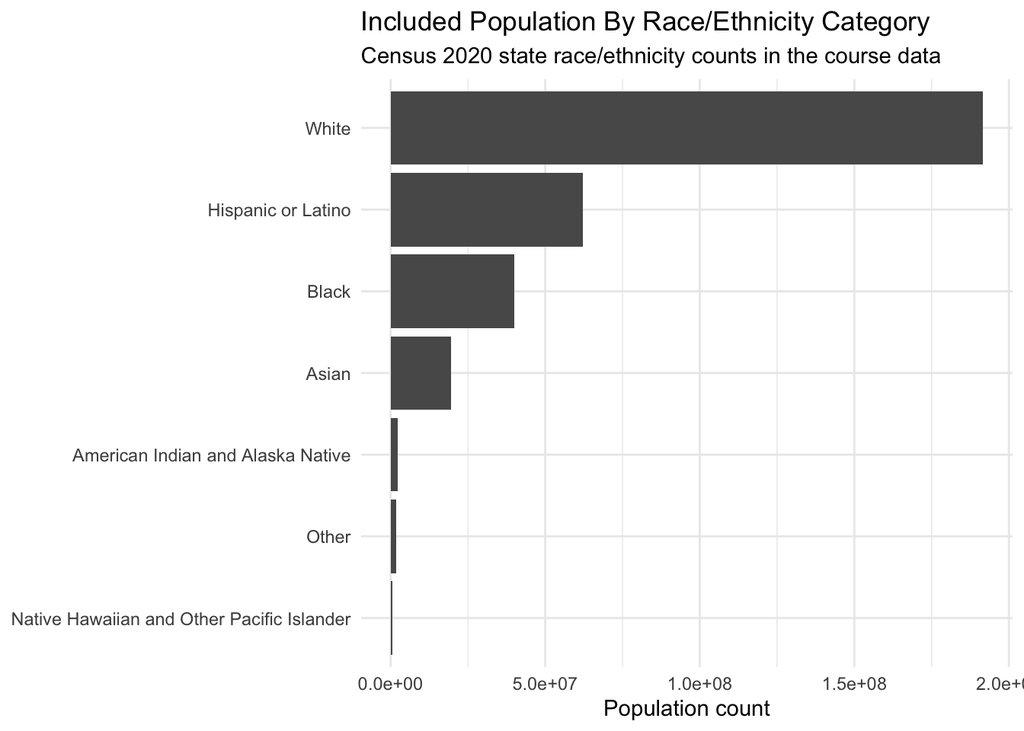

```r
p5 <- p4 +
  labs(
    title = "Included Population By Race/Ethnicity Category",
    subtitle = "Census 2020 state race/ethnicity counts in the course data",
    x = NULL,
    y = "Population count"
  ) +
  theme_minimal()

p5
```

Interpretation: the largest category in this file is White, followed by Hispanic or Latino and Black. The plot is a count of people in the included categories, not a count of states.

# Add A Design Choice

Columns are common for counts, but a dot plot can make rank comparisons feel lighter.

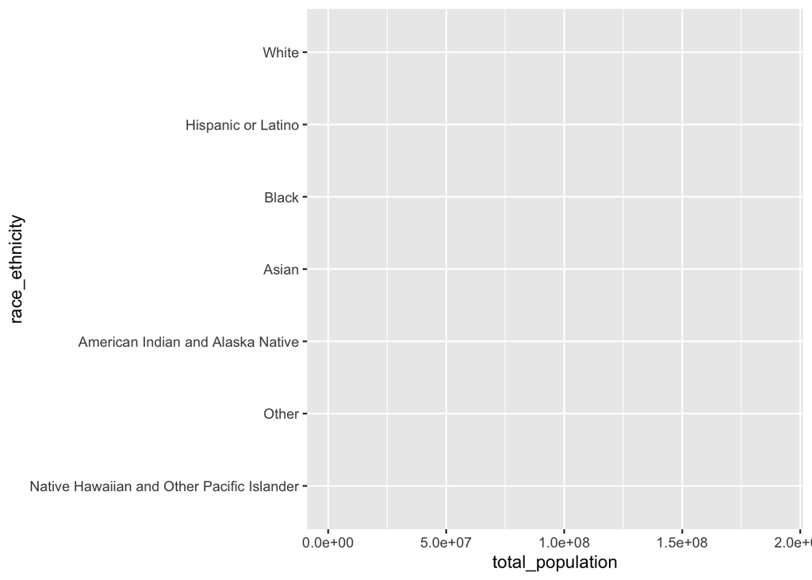

```r
p1 <- ggplot(
  category_population_ordered,
  aes(x = total_population, y = race_ethnicity)
)

p1
```

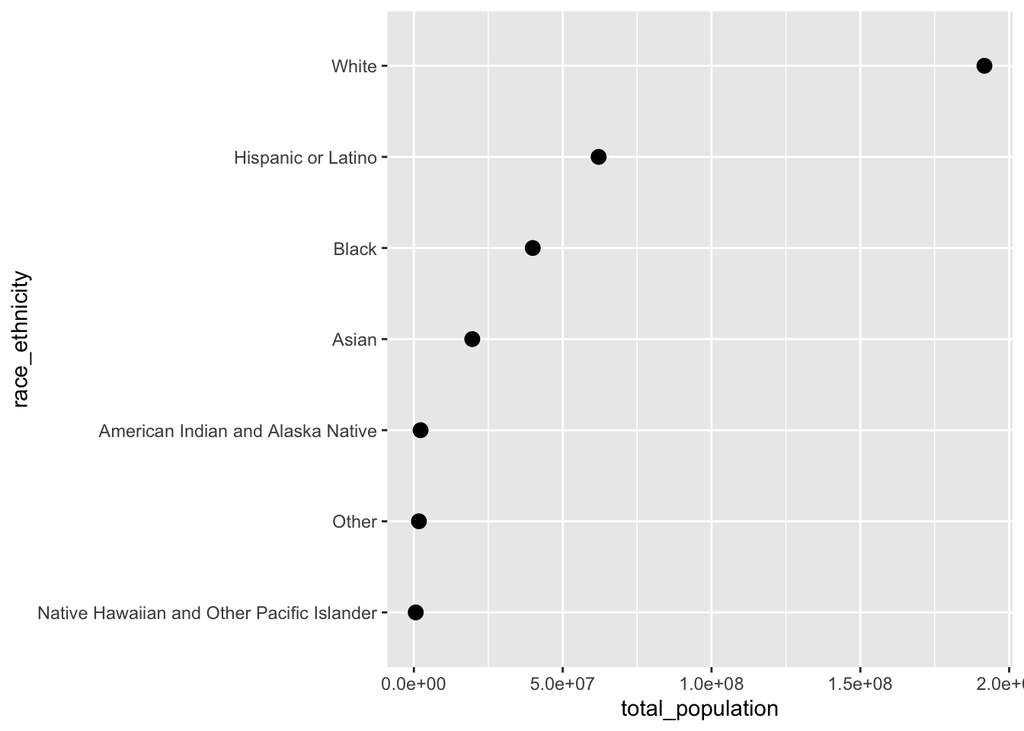

```r
p2 <- p1 +
  geom_point(size = 3)

p2
```

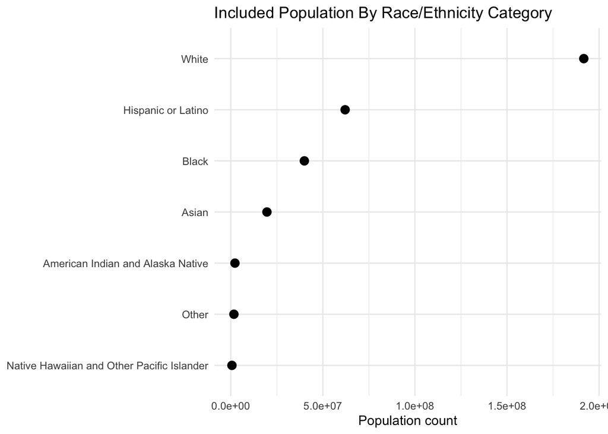

```r
p3 <- p2 +
  labs(
    title = "Included Population By Race/Ethnicity Category",
    x = "Population count",
    y = NULL
  ) +
  theme_minimal()

p3
```

# Takeaways

- Categorical plots depend on what one row represents.
- `geom_bar()` counts rows inside `ggplot2`.
- `geom_col()` uses heights already calculated in the data.
- Ordering categories often makes the plot easier to interpret.
- A count of rows is not the same thing as a count of people, events, or cases.